# simcoal

Simulation of coalescent models

Colin Guétemme

# Aim of this code:

Realise some simulations of a gene tree considering different coalescent model ($n$ and $\beta$).

## ncsim – for the n-coalescent model

### Inputs:

`n` a positive integer for the sample size,

`theta` a positive numeric for the population mutation rate,

`T_total` a logical value to give the total branch length of the tree between each coalescent event (i.e. T_total will be the sum of the time given in output).

### Outputs:

`t` a vector of positive values with the time spent in each state,

`Matstates` a matrix of positive integer with the transient state for this simulation,

`Vecmut` a vector of positive value for the simulated SFS.

```r
ncsim <- function(n, theta = 10, model = 'n', T_total = FALSE){

  if (n <= 0 || length(n) != 1 || round(n) != n){
    stop('n should be a positive integer')
  }
  if (theta < 0 || length(theta) != 1){
    stop('theta should be a positive numeric')
  }
  if (!is.logical(T_total)){
    stop('T_total should be a logical value')
  }
  # Initialisation
  times <- NULL
  T_tot <- NULL

  k <- n  # number of distinct lineages
  count <- 1  # because k will not goes just from 1 to size
  Matstates <- matrix(0, nrow = 1, ncol = n)
  Matstates[1, ] <- c(n, rep(0, n-1))
  Vecnext <- Matstates[1,]
  Vecmut <- rep(0, n-1)  # the number of mutation (in SFS)

  # This loop will continue until reaching the MRCA
  # (until just one lineage)
  while (k > 1){

    # plot(Vecrate)
    # Each coalescent time follow a exp dsitribution
    # with a parameter lambda given by the rate matrix

    lambda <- k*(k-1)/2
    times[count] <- 1/lambda

    if(T_total == TRUE){
      T_tot[count] <- times[count] * k
      }

    # Need this condition because the last coalescent leads to MRCA
    # and is not represented in the state matrix
    # Vector of probability to go to each other states

    inext <- NULL
    # sample two times instead of one (with size 2)
    # to remove 2 of vecnext if the sample choose
    # two times the same lineage size
    for (i in c(1, 2)){
      inext[i] <- sample(x = 1:n, size = 1, prob = Vecnext, replace = TRUE)
      Vecnext[inext[i]] <- Vecnext[inext[i]] - 1
    }
    Vecnext[sum(inext)] <- Vecnext[sum(inext)] + 1
    count <- count + 1
    Matstates <- rbind(Matstates, Vecnext, deparse.level = 0)
    k <- k - 1
  }
  # give a vector of mutation rate (corresponding to the SFS)
  mutrate <- matrix(times * (Matstates[-count, -n]) * (theta/2), ncol = n-1)
  mutrate <- apply(mutrate, 2, sum)
  Vecmut <- rpois(n = n-1, lambda = mutrate)
  if(T_total == TRUE){
    times <- T_tot
    }
  return(list(times, Matstates, Vecmut))
}
```

## Examples

```r
# with T_MRCA

example1 <- ncsim(n = 10)
print(example1)
```

```
## [[1]]
## [1] 0.02222222 0.02777778 0.03571429 0.04761905 0.06666667 0.10000000 0.16666667
## [8] 0.33333333 1.00000000
##
## [[2]]
##       [,1] [,2] [,3] [,4] [,5] [,6] [,7] [,8] [,9] [,10]
##  [1,]   10    0    0    0    0    0    0    0    0     0
##  [2,]    8    1    0    0    0    0    0    0    0     0
##  [3,]    6    2    0    0    0    0    0    0    0     0
##  [4,]    5    1    1    0    0    0    0    0    0     0
##  [5,]    3    2    1    0    0    0    0    0    0     0
##  [6,]    2    2    0    1    0    0    0    0    0     0
##  [7,]    0    3    0    1    0    0    0    0    0     0
##  [8,]    0    2    0    0    0    1    0    0    0     0
##  [9,]    0    1    0    0    0    0    0    1    0     0
## [10,]    0    0    0    0    0    0    0    0    0     1
##
## [[3]]
## [1] 4 7 0 1 0 3 0 5 0
```

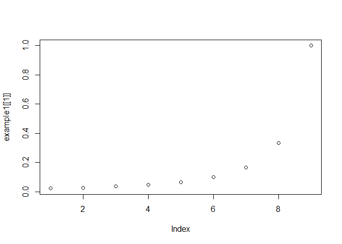

```r
plot(example1[[1]])
```

```r
# with T_Total

example2 <- ncsim(n = 10, theta = 100, T_total = TRUE)
print(example2[[1]])
```

```
## [1] 0.2222222 0.2500000 0.2857143 0.3333333 0.4000000 0.5000000 0.6666667
## [8] 1.0000000 2.0000000
```

```r
print(example2[[3]])
```

```
## [1]  70  52 106  24   0   0  52   0   0
```

Considering many simulations, we can observe the mean SFS of the n-coalescent model. In particular this simulation confirmms that the number of singletons, doubletons, … follows the formula
$$\xi_i = \frac{\theta_i}{i}.$$

**NOTE: THE SIMILAR CODES WILL BE HIDDEN AND LINKED TO THIS ONE, if you need to see the codes, you can check the raw file.**

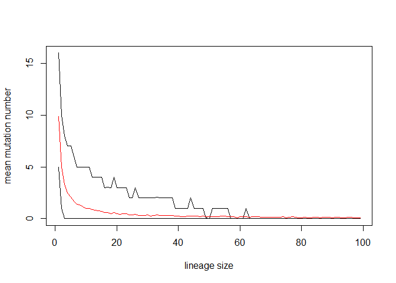

```r
n <- 100
replicate <- 1000
simulationSFS <- matrix(0, ncol = n-1, nrow = replicate)
for (i in 1:replicate){
  simulationSFS[i,] <- ncsim(n = n)[[3]]
}

meanSFS <- apply(simulationSFS, 2, mean)
q1SFS <- apply(simulationSFS, 2, quantile, 0.05)
q2SFS <- apply(simulationSFS, 2, quantile, 0.95)

plot(x = 1:(n-1), y = q2SFS, ylab = 'mean mutation number', xlab = 'lineage size', ylim = c(0, max(q2SFS)), type = 'l')
lines(1:(n-1), meanSFS, col = 'red')
lines(q1SFS)
```

# Variation of the function for other coalescent model

## bcsim – For the $\beta$-coalescent

### Inputs:

`n` a positive integer for the sample size,

`alpha` the alpha parameter for the beta coalescent as $\Lambda \sim \beta(\alpha,\, 2-\alpha)$ should be in the interval $[1,\,2)$

`theta` a positive numeric for the population mutation rate,

`T_total` a logical value to give the total branch length of the tree between each coalescent event (i.e. T_total will be the sum of the time given in output).

### Outputs:

`t` a vector of positive values with the time spent in each state,

`Vecmut`a vector of positive value for the simulated SFS.

This function use the LambdaB() function to calculate the Lambda of the multiple-merger coalescent (according to a Beta). LambdaB() ask the value of $m$, $k$ and $\alpha$ and return the value of the $\Lambda$.

The parameter alpha goes from $[1,2)$, with $1$ is the snisn model, and as $n$ tends to $2$ we approach a Kingman’s coalescent.

```r
LambdaB <- function(m, k, alpha = 1.9999){
  lmk <- beta(k-alpha, m-k+alpha) / beta(alpha, 2-alpha)
  return(lmk)
}

bcsim <- function(n, alpha = 1.9999, theta = 10, T_total = FALSE){
  if (n <= 0 || length(n) != 1 || round(n) != n){
    stop('n should be a positive integer')
  }
  if (theta < 0 || length(theta) != 1){
    stop('theta should be a positive numeric')
  }
  if (!is.logical(T_total)){
    stop('T_total should be a logical value')
  }
  if (alpha < 1 || alpha >= 2 || length(alpha) != 1){
    stop('alpha should be a positive numeric between [1, 2)')
  }
  times <- NULL
  T_tot <- NULL
  k <- n
  count <- 1
  Matstates <- matrix(0, nrow = 1, ncol = n)
  Matstates[1, ] <- c(n, rep(0, n-1))
  Vecnext <- c(n, rep(0, n-1))
  Vecmut <- rep(0, n-1)

  while (k > 1){
    Vecrate <- rep(0, n)
    for (i in 2:k){
      Vecrate[i] <- (LambdaB(k, i, alpha = alpha)) * choose(k, i)
      }
    lambda <- sum(Vecrate)
    times[count] <- 1 / lambda
    kmerger <- sample(1:n, 1, prob = Vecrate / lambda)
    if(T_total == TRUE){
      T_tot[count] <- times[count] * k
      }

    inext <- NULL
    for (i in 1:kmerger){
      inext[i] <- sample(x = 1:n, size = 1, prob = Vecnext, replace = TRUE)
      Vecnext[inext[i]] <- Vecnext[inext[i]] - 1
    }
    Vecnext[sum(inext)] <- Vecnext[sum(inext)] + 1
    count <- count + 1
    Matstates <- rbind(Matstates, Vecnext, deparse.level = 0)
    k <- k - (kmerger-1)
  }

  mutrate <- matrix(times * (Matstates[-count, -n]) * (theta/2), ncol = n-1)
  mutrate <- apply(mutrate, 2, sum)
  Vecmut <- rpois(n = n-1, lambda = mutrate)

  if(T_total == TRUE){
    times <- T_tot
    }
  return(list(times, Matstates, Vecmut))
}
```

## Example of the SFS for the $\beta$-coalescent

Here is the SFS distribution considering a beta coalescent model for 1000 simulations of a sample size $n=100$ and a mutation rate of $\theta = 10$

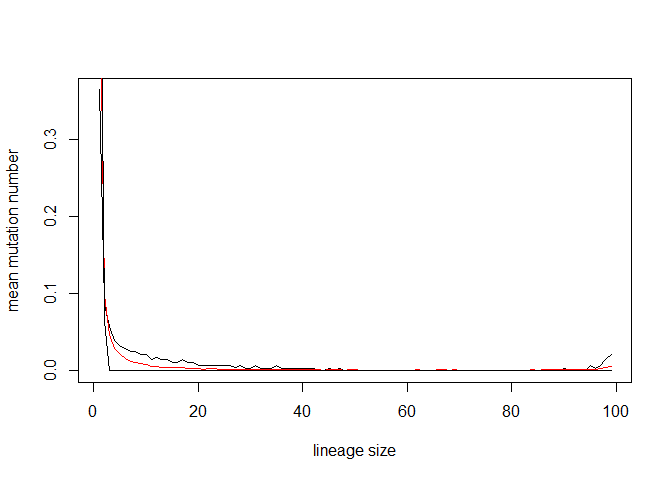

## SFS $n$coalescent vs $\beta$-coalescent

Comparison of the mean SFS distribution for the n model beta model ($n = 100$, $\theta = 10$, replicate $= 1000$)

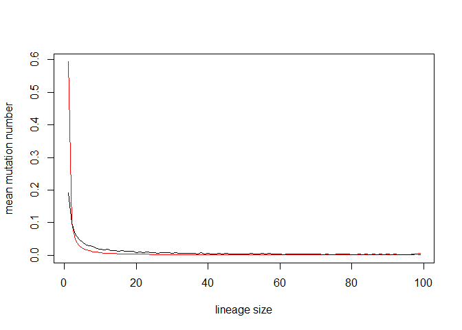

With in red the $\beta$-coalescent model and in black the $n$-coalescent model.

The difference will be mainly on the first few i_tons were the difference is pretty huge with three times more singleton for the $\beta$ coalescent model than for the $n$-coalescent model. This can be explained by the fact that in the $\beta$-coalescent model, many lineages can coalesce in one event so there are less probability to get a particular lineage value (except for the singleton, because there are here at the beginning).

## The singleton distribution (more generally the i_ton distribution)

The singleton distribution given a sample of size n, is the decreasing ordered number (or proportion) of singleton weared by each individual. This statistics will be driven by the states and times to coalescent. Indeed the easiest way to calculate the singleton distribution is to count the number of singleton lineages (the ones which have not coalesce yet, given by the first column of the state matrix) and considering each time before a coalescent event, and to sum all the time before a lineage coalesce. E.g. if the number of singleton lineage before each coalescent event is (4, 2, 1), and the time before each coalescent event is (1, 2, 3), the theoretical distribution of singleton will be proportional to (6, 3, 1, 1). Then we multiply this vector by the population mutation rate. Finally we can sample in a poisson distribution given this vector of rate.

`simultree`: is a list containing the states matrix and the vector of times to coalescent, no default.

`i_ton`: a integral (or vector of integral) which contains the which type of i_ton to look at (i.e. singleton = 1, doubleton = 2, …), the default is singleton.

`theta`: the value of population mutation rate, the default is 10.

### Output

a vector with the i_ton distribution

```r
singletondistr <- function(simultree, i_ton = 1, theta = 10){

  n <- ncol(simultree[[2]])
  individual <- rep(0, n)
  for (i in 1:length(simultree[[1]])){
    nconcerned <- simultree[[2]][i, i_ton]
    individual[1:nconcerned] <- individual[1:nconcerned] + simultree[[1]][i]
  }

  individual <- rpois(n, individual * theta)
  individual <- individual / (sum(individual) + 0.000001)

  return(individual)
}
```

Example of the singleton distribution

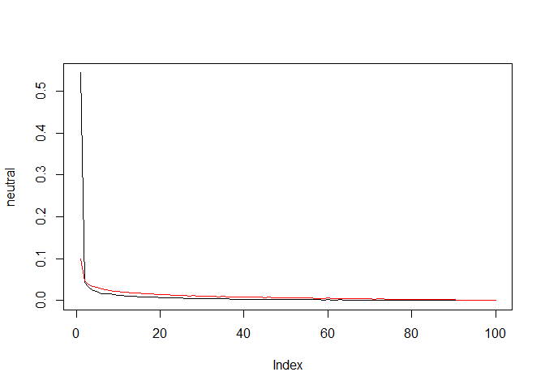

```r
n <- 100
replicate <- 1000

neutral <- matrix(0, ncol = n, nrow = replicate)
MMC <- matrix(0, ncol = n, nrow = replicate)

for (i in 1:replicate){
  sim_neutral <- ncsim(n = n)
  neutral[i,] <- singletondistr(sim_neutral, 1, 10)

  sim_MMC <- bcsim(n = n, alpha = 1)
  MMC[i,] <- singletondistr(sim_MMC, 1, 10)
}

neutral <- apply(neutral, 2, mean)
neutral <- neutral / sum(neutral)

MMC <- apply(MMC, 2, mean)
MMC <- MMC / sum(MMC)

plot(neutral, type = 'l')
lines(MMC, col = 'red')
```

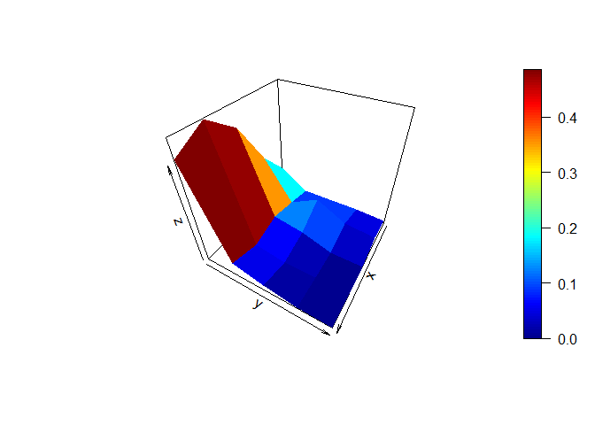

```r
n <- 100

neutral <- matrix(0, ncol = n, nrow = replicate)
MMC <- matrix(0, ncol = n, nrow = replicate)

for (i in 1:n){
  sim_neutral <- bcsim(n = n, alpha = 1.2)
  neutral[i, ] <- singletondistr(sim_neutral, i, 10)
}

require(plot3D)
persp3D(z = neutral[1:5, 1:5], theta = 120)
```